# Project - Statistical Learning

1. Import the necessary libraries

```python
import pandas as pd
import numpy as np
import matplotlib.pyplot as plt
import seaborn as sns
from scipy.stats import skew
```

2. Read the data as a data frame

```python
data = pd.read_csv('insurance.csv')
data.head()
```

|  | age | sex | bmi | children | smoker | region | charges |
| --- | --- | --- | --- | --- | --- | --- | --- |
| 0 | 19 | female | 27.900 | 0 | yes | southwest | 16884.92400 |
| 1 | 18 | male | 33.770 | 1 | no | southeast | 1725.55230 |
| 2 | 28 | male | 33.000 | 3 | no | southeast | 4449.46200 |
| 3 | 33 | male | 22.705 | 0 | no | northwest | 21984.47061 |
| 4 | 32 | male | 28.880 | 0 | no | northwest | 3866.85520 |

3.a. Shape of the data

```python
data.shape
```

```
(1338, 7)
```

**The csv file has 1338 rows/observations and 7 columns/attributes**

3. b. Data type of each attribute

```python
data.info()
```

```
<class 'pandas.core.frame.DataFrame'>
RangeIndex: 1338 entries, 0 to 1337
Data columns (total 7 columns):
age         1338 non-null int64
sex         1338 non-null object
bmi         1338 non-null float64
children    1338 non-null int64
smoker      1338 non-null object
region      1338 non-null object
charges     1338 non-null float64
dtypes: float64(2), int64(2), object(3)
memory usage: 73.2+ KB
```

3. c. Checking the presence of missing values

```python
data.isnull().sum()
```

```
age         0
sex         0
bmi         0
children    0
smoker      0
region      0
charges     0
dtype: int64
```

**There are no null values in given data. However we cannot be sure that all data is valid.There is a possibility of garbage values in the given data.**

3. d. 5 point summary of numerical attributes

```python
data.describe()
```

|  | age | bmi | children | charges |
| --- | --- | --- | --- | --- |
| count | 1338.000000 | 1338.000000 | 1338.000000 | 1338.000000 |
| mean | 39.207025 | 30.663397 | 1.094918 | 13270.422265 |
| std | 14.049960 | 6.098187 | 1.205493 | 12110.011237 |
| min | 18.000000 | 15.960000 | 0.000000 | 1121.873900 |
| 25% | 27.000000 | 26.296250 | 0.000000 | 4740.287150 |
| 50% | 39.000000 | 30.400000 | 1.000000 | 9382.033000 |
| 75% | 51.000000 | 34.693750 | 2.000000 | 16639.912515 |
| max | 64.000000 | 53.130000 | 5.000000 | 63770.428010 |

**As we can see here that describe function automatically ignores categorical data and only shows 5 point summary of numerical attributes.The children attribute is categorical with values between 0 and 5( including both 0 and 5).We can ignore the stats for children attribute.**

```python
data["children"].unique()
```

```
array([0, 1, 3, 2, 5, 4], dtype=int64)
```

3. e. Distribution of ‘bmi’, ‘age’ and ‘charges’ columns

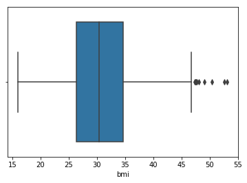

```python
sns.boxplot(x="bmi",data=data)
```

**BMI boxplot suggest that there are outliers at RHS. A slight right skewness is visble**

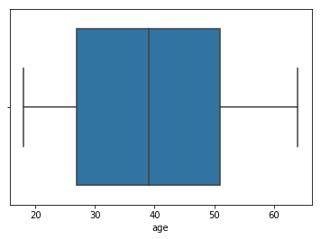

```python
sns.boxplot(x="age",data=data)
```

**Slight Right Skewness but no outliers visible**

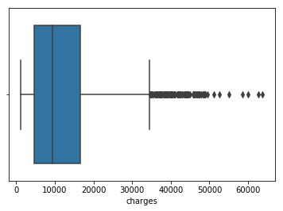

```python
sns.boxplot(x="charges",data=data)
```

**"Charges" are highly right skewed and lot of outliers are present**

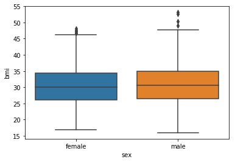

```python
sns.boxplot(x="sex",y="bmi",data=data)
```

**Male bmi distritribution is more skewed.Both male and female bmi distribution has outliers**

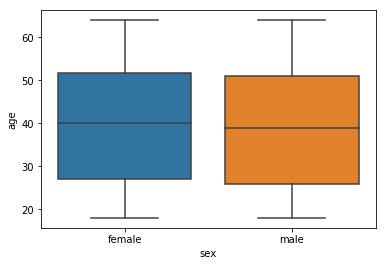

```python
sns.boxplot(x="sex",y="age",data=data)
```

**Age distribution for both male and female seems comparable.No Outliers**

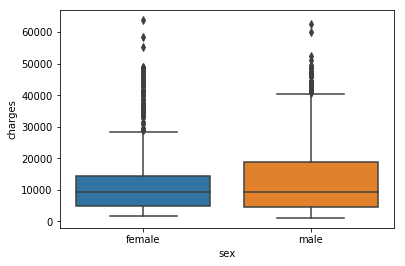

```python
sns.boxplot(x="sex",y="charges",data=data)
```

**The male and female charges are highly right skewed with a lot of outliers**

3. f. Measure of skewness of ‘bmi’, ‘age’ and ‘charges’ columns

**Skewness is the measure of asymmetry of distribution of values around the mean**

**skewness = 0 :** normally distributed.  
**skewness > 0 :** more weight in the left tail of the distribution.  
**skewness < 0 :** more weight in the right tail of the distribution.

```python
data.skew()
```

```
age         0.055673
bmi         0.284047
children    0.938380
charges     1.515880
dtype: float64
```

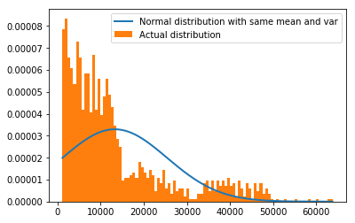

```python
import scipy.stats as stats

#convert pandas DataFrame object to numpy array and sort
h = np.asarray(data['charges'])
h = sorted(h)

#use the scipy stats module to fit a normal distirbution with same mean and standard deviation
fit = stats.norm.pdf(h, np.mean(h), np.std(h))

#plot both series on the histogram
plt.plot(h,fit,'-',linewidth = 2,label="Normal distribution with same mean and var")
plt.hist(h,normed=True,bins = 100,label="Actual distribution")
plt.legend()
plt.show()
```

Ignoring the categorical attribute children, we can see that age, bmi and charges are right skewed( all values positive). Out of these charges is highly skewed.

3. g. Checking the presence of outliers in ‘bmi’, ‘age’ and ‘charges columns

Scatter Plot for ‘bmi’, ‘age’ and ‘charges’

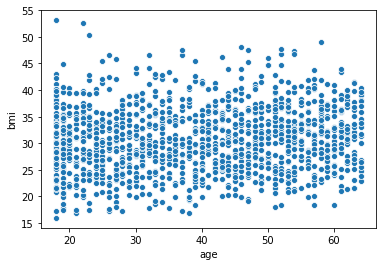

```python
sns.scatterplot(x="age",y="bmi",data=data)
```

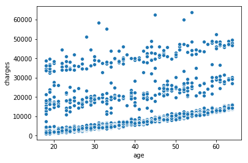

```python
sns.scatterplot(x="age",y="charges",data=data)
```

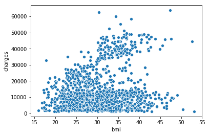

```python
sns.scatterplot(x="bmi",y="charges",data=data)
```

3. h. Distribution of categorical columns (include children)

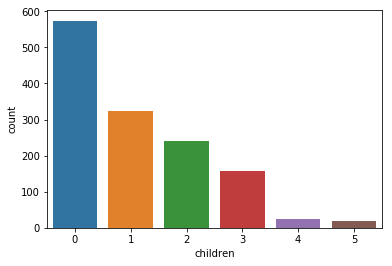

```python
sns.countplot(x="children",data=data)
```

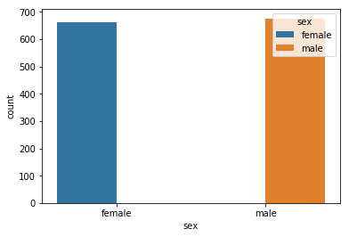

```python
sns.countplot(x="sex",data=data,hue="sex")
```

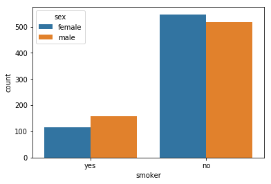

```python
sns.countplot(x="smoker",data=data,hue="sex")
```

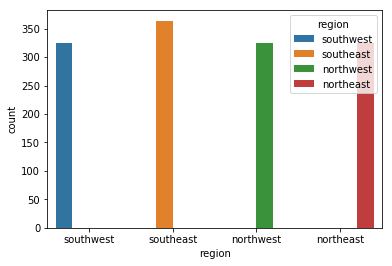

```python
sns.countplot(x="region",data=data,hue="region")
```

3.i. Pair plot that includes all the columns of the data frame

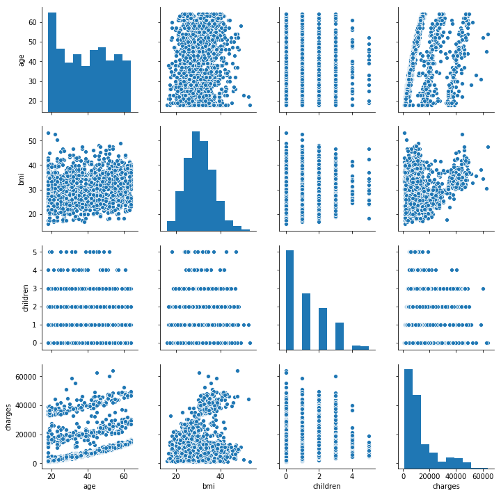

```python
sns.pairplot(data=data)
```

The presence of segregated scatter plots such as age vs children means that one of the variable is categorical in nature.Here the children is a categorical variable.

# HYPOTHESIS TESTING

4. a. Do charges of people who smoke differ significantly from the people who don't?

- Stating the Hypothesis

#### Ho : Charges of people who smoke is same as those who don't

#### Ha : Charges of people who smoke and those who don't are different

```python
from scipy.stats import ttest_ind
```

```python
sample1  = data[data["smoker"]=='yes']
sample2 = data[data["smoker"]=='no']
```

```python
#statistical significance level 0.05
# two-sample t-test
# null hypothesis: the two groups have the same mean
# this test assumes the two groups variance is not equal( Welch's T-Test)
t_statistic, p_value = ttest_ind(sample1["charges"], sample2["charges"],equal_var=False)
print(t_statistic, p_value)
```

```
32.751887766341824 5.88946444671698e-103
```

```python
# p_value < 0.05 => alternative hypothesis:
# they don't have the same mean at the 5% significance level
print ("two-sample t-test p-value=", p_value)
```

```
two-sample t-test p-value= 5.88946444671698e-103
```

#### Since p-value is very low below the significance level , we can reject the null hypothesis that the charges are same for smoker's and non-smokers

4. b. Does bmi of males differ significantly from that of females?

```python
data["sex"].value_counts()
```

```
male      676
female    662
Name: sex, dtype: int64
```

```python
sample_male = data[data['sex'] == 'male'].bmi.iloc[:-14]   #excluding the last 14 elements to match the size 2 samples
sample_female = data[data['sex'] == 'female'].bmi
sample_female.head()
```

```
0    27.90
5    25.74
6    33.44
7    27.74
9    25.84
Name: bmi, dtype: float64
```

```python
v1, v2 = np.var(sample_female) , np.var(sample_male)
print(v1,v2)
```

```
36.49917703379856 37.060771284489896
```

- Variances of bmi of men is higher than it is for women. But is the difference statistically significant.

#### Ho : Variation in bmi of men and women is equal same

#### Ha : Variation in bmi of men is greater than it is in women

```python
#statistical significance level 0.05
# two-sample t-test
# null hypothesis: the two groups have the same mean
# this test assumes the two groups variance is equal
t_statistic, p_value = ttest_ind(sample_male, sample_female,equal_var=True)
print(t_statistic, p_value)
```

```
1.4909428836389147 0.1362150480986335
```

#### The p-value of 0.136 is higher than the statistical significance of 0.05. Hence we fail to reject the null hypothesis that bmi of men and women is same

4. c. Is the proportion of smokers significantly different in different genders?

- 'sex' and 'smoker' are two categorical variables
- We want to see if the proportion of smokers in the female population is significantly different than it is in the male population

#### Ho = The proportions are equal

#### Ha = The two proportions are not equal

```python
female_smokers = data[data['sex'] == 'female'].smoker.value_counts()[1]  # number of female smokers
male_smokers = data[data['sex'] == 'male'].smoker.value_counts()[1] # number of male smokers
n_females = data.sex.value_counts()[1] # number of females in the data
n_males = data.sex.value_counts()[0] #number of males in the data
```

```python
print([female_smokers, male_smokers] , [n_females, n_males])
print(f' Proportion of smokers in females, males = {round(115/662,2)}%, {round(159/676,2)}% respectively')
```

[output not shown]

The proportions are different but are they statistically significant?

```python
from statsmodels.stats.proportion import proportions_ztest

stat, pval = proportions_ztest([female_smokers, male_smokers] , [n_females, n_males])

if pval < 0.05:
    print(f'With a p-value of {round(pval,4)} the difference is significant. aka |We reject the null|')
else:
    print(f'With a p-value of {round(pval,4)} the difference is not significant. aka |We fail to reject the null|')
```

```
With a p-value of 0.0053 the difference is significant. aka |We reject the null|
```

```python
data0 = data[(data.children==0) & (data.sex=="female")]
data1 = data[(data.children==1) & (data.sex=="female")]
data2 = data[(data.children==2) & (data.sex=="female")]
```

```python
print('Mean and standard deviation of bmi for women with children 0: %3.2f and %3.2f' % (data0["bmi"].mean(),np.std(data0["bmi"],ddof =1)))
print('Mean and standard deviation of bmi for women with children 1: %3.2f and %3.2f' % (data1["bmi"].mean(),np.std(data1["bmi"],ddof =1)))
print('Mean and standard deviation of bmi for women with children 2: %3.2f and %3.2f' % (data2["bmi"].mean(),np.std(data2["bmi"],ddof =1)))
```

```
Mean and standard deviation of bmi for women with children 0: 30.36 and 5.97
Mean and standard deviation of bmi for women with children 1: 30.05 and 5.79
Mean and standard deviation of bmi for women with children 2: 30.65 and 6.63
```

```python
mean_bmi_df = pd.DataFrame()

mean_bmi_df = mean_bmi_df.append(data0)
mean_bmi_df = mean_bmi_df.append(data1)
mean_bmi_df = mean_bmi_df.append(data2)

mean_bmi_df.head()
```

|  | age | sex | bmi | children | smoker | region | charges |
| --- | --- | --- | --- | --- | --- | --- | --- |
| 0 | 19 | female | 27.90 | 0 | yes | southwest | 16884.92400 |
| 5 | 31 | female | 25.74 | 0 | no | southeast | 3756.62160 |
| 9 | 60 | female | 25.84 | 0 | no | northwest | 28923.13692 |
| 11 | 62 | female | 26.29 | 0 | yes | southeast | 27808.72510 |
| 13 | 56 | female | 39.82 | 0 | no | southeast | 11090.71780 |

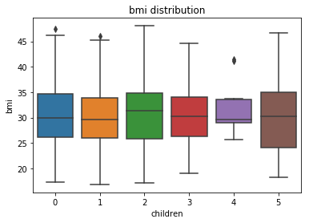

```python
sns.boxplot(x = "children", y = "bmi", data = data[data["sex"]=="female"])
plt.title('bmi distribution')
plt.show()

# ignore distribution of bmi for women with 3 and more children
```

```python
%matplotlib inline
import statsmodels.api as sm
from statsmodels.formula.api import ols
```

### Step 1: State the null and alternative hypothesis:

- $H_0$: $\mu1$ = $\mu2$ = $\mu3$
- $H_A$: At least one $\mu$ differs

Here $\mu1$, $\mu2$ and $\mu3$ are the mean of bmi for women with 0 , 1 and 2 children respectively

### Step 2: Decide the significance level

Here we select α = 0.05

```python
mod = ols('sex ~ children', data = mean_bmi_df).fit()
aov_table = sm.stats.anova_lm(mod, typ=2)
print(aov_table)
```

```
                sum_sq     df          F        PR(>F)
children  2.213948e-28    1.0  455.46201  1.585603e-74
Residual  2.741538e-28  564.0        NaN           NaN
```

**--------------------------------------------------Thank you-----------------------------------------------**